# Guía Modelos Lineales Generales

Diplomado Análisis de datos con R para la acuicultura

Dr. José A. Gallardo y Dra. María Angélica Rueda.

Pontificia Universidad Católica de Valparaíso  
jose.gallardo@pucv.cl

28 May 2022

### MODELOS LINEALES GENERALES

Los modelos lineales generales extienden a los modelos lineales clásicos admitiendo distribuciones no normales para la variable respuesta y modelando funciones de la media.

Los MLG son, por tanto, una extensión de los modelos lineales que permiten utilizar distribuciones no normales de los errores (binomiales, Poisson, gamma, etc) y varianzas no constantes.

Características de un modelo lineal general (MLG)

1). La variable respuesta/residuos pueden tener distribución normal u otros tipos de distribuciones.

2). Existencia de observaciones correlacionadas.

3). Puede existir heterogeneidad de varianzas.

Incumplimiento de los supuestos:

1. Hay observaciones correlacionadas.
2. Los residuos se pueden o no distribuir **normalmente**.
3. Varianza no constante.

#### **Objetivos de aprendizaje**

Los objetivos de aprendizaje de esta guía son:

**1**. - Ajustar modelos lineales generales.

**2**. - Realizar gráficas.

**3**. - Elaborar un reporte dinámico en formato html con **[Rmarkdown](https://rmarkdown.rstudio.com/)**.

## ESTUDIO DE CASO: MADURACIÓN SALMÓN DEL ATLÁNTICO

En este estudio de caso trabajaremos con un set de datos de 120 observaciones extraídas del set de datos original del paper de Fraser et.al., 2019. [Fuente: Fraser et.al 2019](https://www.sciencedirect.com/science/article/pii/S0044848619315546?via%3Dihub)

La variable respuesta se denomina **Mature** y las variables predictoras **Length** y **Mass**.

**Mature:** Estado de maduración de los salmones **Lenght:** Tamaño de los salmones **Mass:** Peso corporal

## **Ejercicio 1.** Elaborar y configurar Reporte en formato .Rmd

Elabore un documento .Rmd y configure su reporte para exportar en html. Instale solo las librerías que utilice para el análisis de los datos.

```r
knitr::opts_chunk$set(echo = TRUE)
library(readxl)
library(ggplot2)
library(multcomp)
library(psych)
library(car)
library(readr)
library(lmtest)
library(boot)
```

Ejecute cada uno de los siguientes ejercicios en uno o más bloques de códigos diferentes. Sea ordenado y documente su reporte adecuadamente.

## **Ejercicio 2.** Exploratorio set de datos Salmon_maturation_data.xlsx

Importe el set de datos **Salmon_maturation_data.xlsx** y realice un análisis exploratorio de datos.

Incluya:

**a).** Resumen estadístico de todas las variables.

```r
Salmon_maturation_data <- read_excel("Salmon_maturation_data.xlsx")
summary(Salmon_maturation_data)
```

```
##       Fish             Mass          Length         LogMass
##  Min.   :  6.00   Min.   : 271   Min.   :27.50   Min.   :2.430
##  1st Qu.: 27.75   1st Qu.:1544   1st Qu.:46.50   1st Qu.:3.190
##  Median : 43.50   Median :2668   Median :55.25   Median :3.425
##  Mean   :187.64   Mean   :2804   Mean   :54.68   Mean   :3.379
##  3rd Qu.:395.25   3rd Qu.:3786   3rd Qu.:63.00   3rd Qu.:3.580
##  Max.   :716.00   Max.   :6225   Max.   :72.50   Max.   :3.790
##    LogLength         Mature
##  Min.   :1.439   Min.   :0.0
##  1st Qu.:1.667   1st Qu.:0.0
##  Median :1.742   Median :0.5
##  Mean   :1.730   Mean   :0.5
##  3rd Qu.:1.799   3rd Qu.:1.0
##  Max.   :1.860   Max.   :1.0
```

**b).** Ajuste un modelo lineal general (**Regresión logística simple**) donde la variable **Mature** es la variable respuesta y la variable **Length** es la variable predictora. Use la función **glm()** y haga el **summary()** del modelo.

```r
modelo1 <- glm(Mature ~ Length,
                family= binomial, data = Salmon_maturation_data)
summary(modelo1)
```

```
##
## Call:
## glm(formula = Mature ~ Length, family = binomial, data = Salmon_maturation_data)
##
## Deviance Residuals:
##      Min        1Q    Median        3Q       Max
## -1.53394  -1.05066   0.02843   1.13623   1.72749
##
## Coefficients:
##             Estimate Std. Error z value Pr(>|z|)
## (Intercept) -2.48715    1.05921  -2.348   0.0189 *
## Length       0.04545    0.01902   2.389   0.0169 *
## ---
## Signif. codes:  0 '***' 0.001 '**' 0.01 '*' 0.05 '.' 0.1 ' ' 1
##
## (Dispersion parameter for binomial family taken to be 1)
##
##     Null deviance: 166.36  on 119  degrees of freedom
## Residual deviance: 160.33  on 118  degrees of freedom
## AIC: 164.33
##
## Number of Fisher Scoring iterations: 4
```

**c).** Realice el diagrama de dispersión de **Mature** *vs* **Length** usando la función geom_point() y use la función geom_smooth(method = “glm”, method.args = list(family = “binomial”)). Colocar título, nombre del eje x, nombre del eje y. Usar tema **theme_bw()**

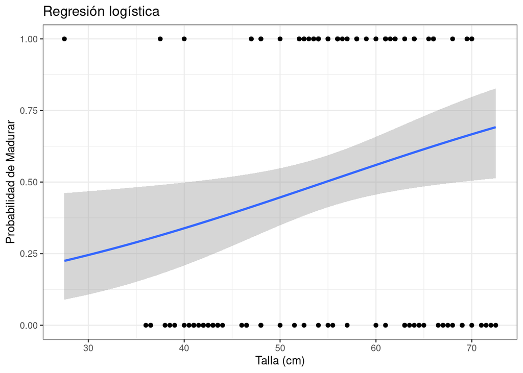

**d).** Ajuste un modelo lineal general (**Regresión logística múltiple**) donde la variable **Mature** es la variable respuesta y las variables **Length** y **Mass** como variables predictoras. Use la función **glm()** y haga el **summary()** del modelo.

```r
modelo2 <- glm(Mature ~ Length + Mass,
                family= binomial, data = Salmon_maturation_data)
summary(modelo2)
```

```
##
## Call:
## glm(formula = Mature ~ Length + Mass, family = binomial, data = Salmon_maturation_data)
##
## Deviance Residuals:
##      Min        1Q    Median        3Q       Max
## -1.85540  -0.97250   0.00173   0.95998   2.78291
##
## Coefficients:
##               Estimate Std. Error z value Pr(>|z|)
## (Intercept) -12.451405   2.943351  -4.230 2.33e-05 ***
## Length        0.333063   0.080100   4.158 3.21e-05 ***
## Mass         -0.002063   0.000548  -3.765 0.000167 ***
## ---
## Signif. codes:  0 '***' 0.001 '**' 0.01 '*' 0.05 '.' 0.1 ' ' 1
##
## (Dispersion parameter for binomial family taken to be 1)
##
##     Null deviance: 166.36  on 119  degrees of freedom
## Residual deviance: 142.76  on 117  degrees of freedom
## AIC: 148.76
##
## Number of Fisher Scoring iterations: 3
```

**e).** Compare los modelos de regresión logítica simple y múltiple de los items anteriores usando el críterio de AIC. Use la función **AIC()**. Diga según el criterio de AIC ¿Cuál sería el mejor modelo?

```r
AIC(modelo1,modelo2)
```

```
##         df      AIC
## modelo1  2 164.3312
## modelo2  3 148.7615
```

**f).** Compare los modelos de regresión logítica simple y múltiple de los items anteriores haciendo un anova. Use la función **anova(modelo1, modelo2,test =‘Chisq’)**. Diga cuál sería el mejor modelo y porqué?

```r
anova(modelo1,modelo2,test ='Chisq')
```

```
## Analysis of Deviance Table
##
## Model 1: Mature ~ Length
## Model 2: Mature ~ Length + Mass
##   Resid. Df Resid. Dev Df Deviance Pr(>Chi)
## 1       118     160.33
## 2       117     142.76  1    17.57 2.77e-05 ***
## ---
## Signif. codes:  0 '***' 0.001 '**' 0.01 '*' 0.05 '.' 0.1 ' ' 1
```

### **Ejercicio 3.** ESTUDIO DE CASO: DATOS CANGREJOS

El set de **Datos_cangrejos.xslx** son 173 datos de cangrejos herradura hembras de la librería de R (glmbb) llamada *crabs*. Donde se les midieron 6 variables. Ver descripción de dataset en https://cran.r-project.org/web/packages/glmbb/glmbb.pdf

**a).** Resumen estadístico de todas las variables.

```r
Datos_cangrejos <- read_excel("Datos_cangrejos.xlsx")
summary(Datos_cangrejos)
```

```
##     color              spine               width          satell
##  Length:173         Length:173         Min.   :21.0   Min.   : 0.000
##  Class :character   Class :character   1st Qu.:24.9   1st Qu.: 0.000
##  Mode  :character   Mode  :character   Median :26.1   Median : 2.000
##                                        Mean   :26.3   Mean   : 2.919
##                                        3rd Qu.:27.7   3rd Qu.: 5.000
##                                        Max.   :33.5   Max.   :15.000
##      weight           y
##  Min.   :1200   Min.   :0.0000
##  1st Qu.:2000   1st Qu.:0.0000
##  Median :2350   Median :1.0000
##  Mean   :2437   Mean   :0.6416
##  3rd Qu.:2850   3rd Qu.:1.0000
##  Max.   :5200   Max.   :1.0000
```

**b).** Ajuste un modelo lineal general (**Regresión logística simple**) donde la variable **y** es la variable respuesta y la variable **weight** es la variable predictora. Use la función **glm()** y haga el **summary()** del modelo.

```r
modelo3 <- glm(y ~ weight,
                family= binomial, data = Datos_cangrejos)
summary(modelo3)
```

```
##
## Call:
## glm(formula = y ~ weight, family = binomial, data = Datos_cangrejos)
##
## Deviance Residuals:
##     Min       1Q   Median       3Q      Max
## -2.1108  -1.0749   0.5426   0.9122   1.6285
##
## Coefficients:
##               Estimate Std. Error z value Pr(>|z|)
## (Intercept) -3.6947264  0.8801975  -4.198 2.70e-05 ***
## weight       0.0018151  0.0003767   4.819 1.45e-06 ***
## ---
## Signif. codes:  0 '***' 0.001 '**' 0.01 '*' 0.05 '.' 0.1 ' ' 1
##
## (Dispersion parameter for binomial family taken to be 1)
##
##     Null deviance: 225.76  on 172  degrees of freedom
## Residual deviance: 195.74  on 171  degrees of freedom
## AIC: 199.74
##
## Number of Fisher Scoring iterations: 4
```

**c).** Realice el diagrama de dispersión de **y** *vs* **weight** usando la función geom_point() y use la función geom_smooth(method = “glm”, method.args = list(family = “binomial”)). Colocar título, nombre del eje x, nombre del eje y. Usar tema **theme_bw()**

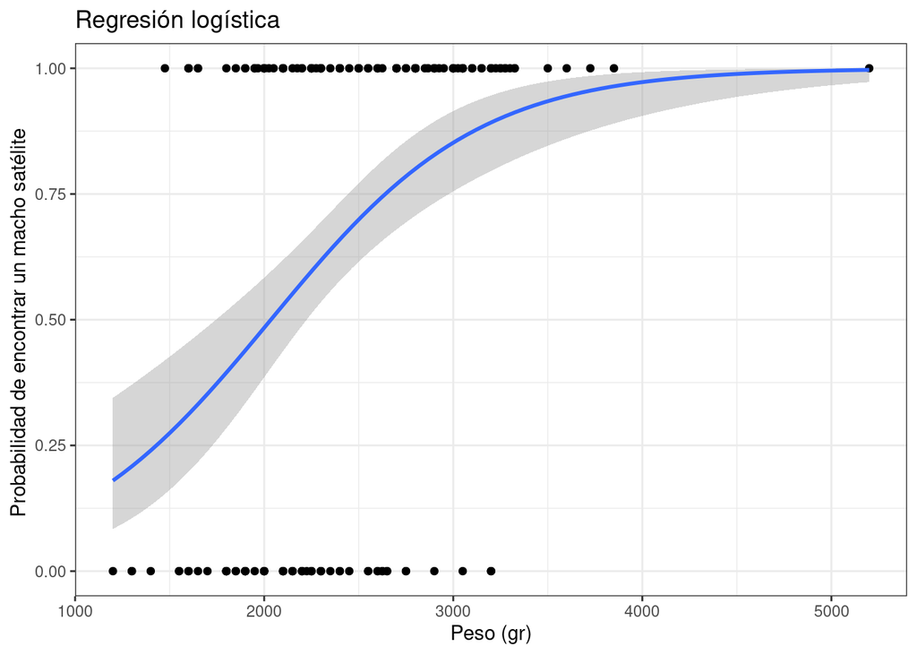

**d).** Ajuste un modelo lineal general (**Regresión logística múltiple**) donde la variable **y** es la variable respuesta y las variables **weight** y **width** como variables predictoras. Use la función **glm()** y haga el **summary()** del modelo.

```r
modelo4 <- glm(y ~ weight + width,
                family= binomial, data = Datos_cangrejos)
summary(modelo4)
```

```
##
## Call:
## glm(formula = y ~ weight + width, family = binomial, data = Datos_cangrejos)
##
## Deviance Residuals:
##     Min       1Q   Median       3Q      Max
## -2.1127  -1.0344   0.5304   0.9006   1.7207
##
## Coefficients:
##               Estimate Std. Error z value Pr(>|z|)
## (Intercept) -9.3547261  3.5280465  -2.652  0.00801 **
## weight       0.0008338  0.0006716   1.241  0.21445
## width        0.3067892  0.1819473   1.686  0.09177 .
## ---
## Signif. codes:  0 '***' 0.001 '**' 0.01 '*' 0.05 '.' 0.1 ' ' 1
##
## (Dispersion parameter for binomial family taken to be 1)
##
##     Null deviance: 225.76  on 172  degrees of freedom
## Residual deviance: 192.89  on 170  degrees of freedom
## AIC: 198.89
##
## Number of Fisher Scoring iterations: 4
```

**e).** Compare los modelos de regresión logítica simple y múltiple de los items anteriores usando el críterio de BIC. Use la función **BIC()**. Diga según el criterio de BIC ¿Cuál sería el mejor modelo? **Nota: Un valor menor de BIC indica mejor modelo.**

```r
BIC(modelo3,modelo4)
```

```
##         df      BIC
## modelo3  2 206.0437
## modelo4  3 208.3518
```

**f).** Compare los modelos de regresión logítica simple y múltiple de los items anteriores haciendo un anova. Use la función **anova(modelo3, modelo4,test =‘Chisq’)**. Diga cuál sería el mejor modelo y porqué?

```r
anova(modelo3,modelo4,test ='Chisq')
```

```
## Analysis of Deviance Table
##
## Model 1: y ~ weight
## Model 2: y ~ weight + width
##   Resid. Df Resid. Dev Df Deviance Pr(>Chi)
## 1       171     195.74
## 2       170     192.89  1   2.8453  0.09164 .
## ---
## Signif. codes:  0 '***' 0.001 '**' 0.01 '*' 0.05 '.' 0.1 ' ' 1
```